# Capstone: Yelp Data Analysis

Sau-Chin Chen

# Get Data

This project will analyze the data set from [Yelp Dataset Challenge](http://www.yelp.com/dataset_challenge). The data set is downloaded from [this link](https://d396qusza40orc.cloudfront.net/dsscapstone/dataset/yelp_dataset_challenge_academic_dataset.zip). I obtained and pre-processed the data set through the codes in 0GetData.R. Here are files compressed in the zip file:

```
##                                                                                       Name
## 1                                                 yelp_dataset_challenge_academic_dataset/
## 2 yelp_dataset_challenge_academic_dataset/Dataset_Challenge_Academic_Dataset_Agreement.pdf
## 3              yelp_dataset_challenge_academic_dataset/yelp_academic_dataset_business.json
## 4               yelp_dataset_challenge_academic_dataset/yelp_academic_dataset_checkin.json
## 5                yelp_dataset_challenge_academic_dataset/yelp_academic_dataset_review.json
## 6                   yelp_dataset_challenge_academic_dataset/yelp_academic_dataset_tip.json
## 7                  yelp_dataset_challenge_academic_dataset/yelp_academic_dataset_user.json
## 8         yelp_dataset_challenge_academic_dataset/Yelp_Dataset_Challenge_Terms_round_5.pdf
##       Length                Date
## 1          0 2015-02-05 02:38:00
## 2     145931 2015-02-05 02:38:00
## 3   55412111 2015-01-23 00:47:00
## 4   20664236 2015-01-23 00:49:00
## 5 1426365176 2015-01-23 00:49:00
## 6   98451808 2015-01-23 00:49:00
## 7  166192435 2015-01-23 00:49:00
## 8     114263 2015-02-05 02:38:00
```

Yelp is collecting the users’ review for the businesses around the major cities across North America and Europe. Data set *business* collects the information from 61184 businesses. Data set *checkin* stores 45166 durations and frequencies a user stay in every business. Data set *review* sumarizes 1569264 reviews for a registed business. Data set *tip* summarizes the 495107 recommendations for a business. Data set *user* collects the information from 366715 registed users.

# Question and hypothesis

If the data set could show us the variables how users evaluate a businesses, Will we figure a global standard across cities or many local standards in each city?  
If one set of variables gathered from one city could cluster the businesses in the other city, they represent the global standard for this business. Otherwise, every city has the local standard.

# Preprocess Raw Business Data

## Adjust the locations of businesses

Although each bussines in the business data set has the information of its location (full_address, city, state), these information are a mass because there are many users’ typo. We use the geographical information (longitude, latitude) to adjust the location of each business. The result is that we add the new column ‘Loc’ to the business data set with the following codes.

```
yelp_business <- data.frame(yelp_business, Loc = City_Tag(yelp_business$latitude, yelp_business$longitude))
```

## Decide the categories for this project

When we focus on the one category of business, such as Pizza or Chinese restaurants, we could compute the relations of attributes and stars of businesses. At first, We calcuated how many categories are collected in the data set and how many businesses are labeled in every category. Here are the top 30 categories. We find out some comparable categories in this list. For example, “Fast Food” and “Pizza”; “Chinese” and “Italian”.

```
##
##               Restaurants                  Shopping
##                     21892                      8919
##                      Food             Beauty & Spas
##                      7862                      4738
##                 Nightlife                      Bars
##                      4340                      3628
##          Health & Medical                Automotive
##                      3213                      2965
##             Home Services                   Fashion
##                      2853                      2566
##               Active Life Event Planning & Services
##                      2470                      2467
##                 Fast Food                     Pizza
##                      2383                      2223
##                   Mexican            Local Services
##                      2208                      2144
##           Hotels & Travel    American (Traditional)
##                      2131                      2113
##                Sandwiches      Arts & Entertainment
##                      1981                      1946
##              Coffee & Tea                   Italian
##                      1890                      1633
##                   Chinese            American (New)
##                      1496                      1494
##                   Burgers               Hair Salons
##                      1481                      1388
##                    Hotels               Nail Salons
##                      1307                      1256
##                   Grocery               Auto Repair
##                      1233                      1220
```

We pick up Fast Food and Chinese resturant as the cases.

## Modifications on the variables

1. Delete the variables captured less than 10% observations
2. Transfer all attribute vectors to numerics
3. Tag variable names with simple characters

# Baysian Belief Network

We used the package **bnlearn** [Tutorial of **bnlearn**](http://www.jstatsoft.org/v35/i03/)

# Explore category data in BBN

Fixed: categories

## variables in analysis

Primary: stars(numeric) secondary: Loc(city -> Factor), neighborhoods(numbers), hours(types -> numeric) Third: attributes(numbers, NA -> 0, 1 -> 2, 2 -> 3, etc.)

## Summary after exploration

- Stars show the common evaluation for fast food. Fast food in each city has a specific set of variables to influence the stars People evalute the Chinese resturants on a specific attributes rather than a score. Generally the attributes are “Outdoor.Seating” and “Has.TV”.

[figure not shown]

- Somethings are more important than stars for the guests of Chinese resturants “Loc” decide the hours of open of Chinese resturants. Hours of open directly influence “stars”. “Loc” and “stars” decide the other attributes of Chinese resturants.  
  “Outdoor.Seating” and “Has.TV” are the notes without children.

[figure not shown]

# Build evaluation model for fast food in Phoenix

We set alpha = 0 because some attributes had to dependend on the other attributes.

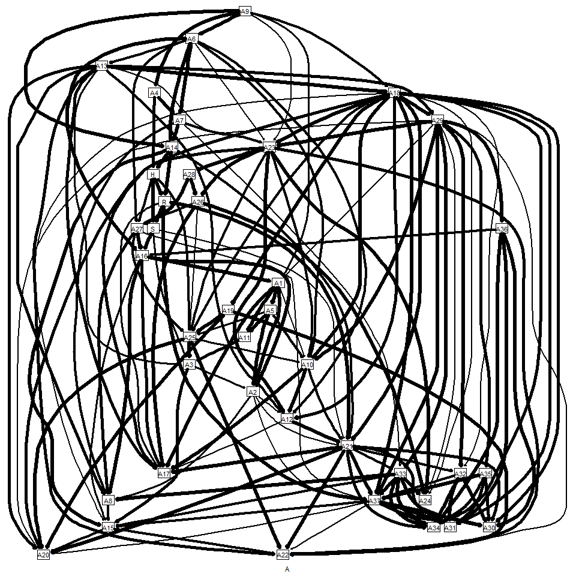

The start is Attire. The final nodes are validated, valet, intimate, classy, touristy.

# Build evaluation model for fast food in Charlotte

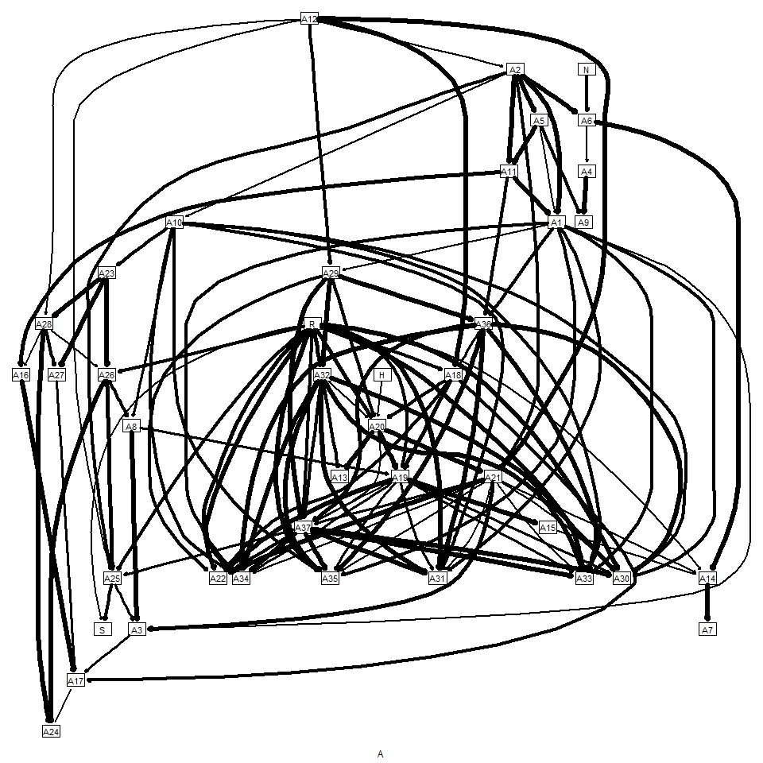

The start is Delivery. The final nodes are stars, Noise.Level, Wheelchair.Accessible, valet, intimate, classy, divey, touristy, trendy.

# Build evaluation model for Chinese resturants in Phoenix

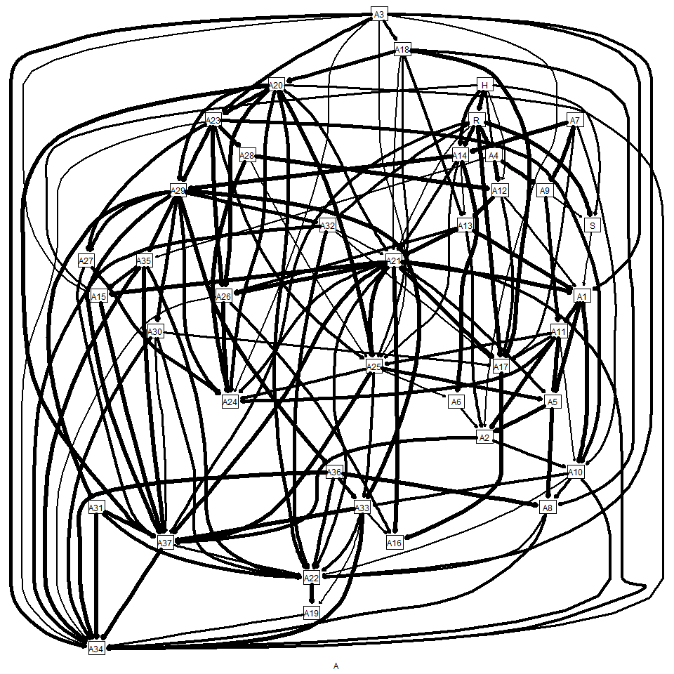

The start is Outdoor.Seating. The final notes are Drive.Thru, touristy

# Build evaluation model for Chinese resturants in Charlotte

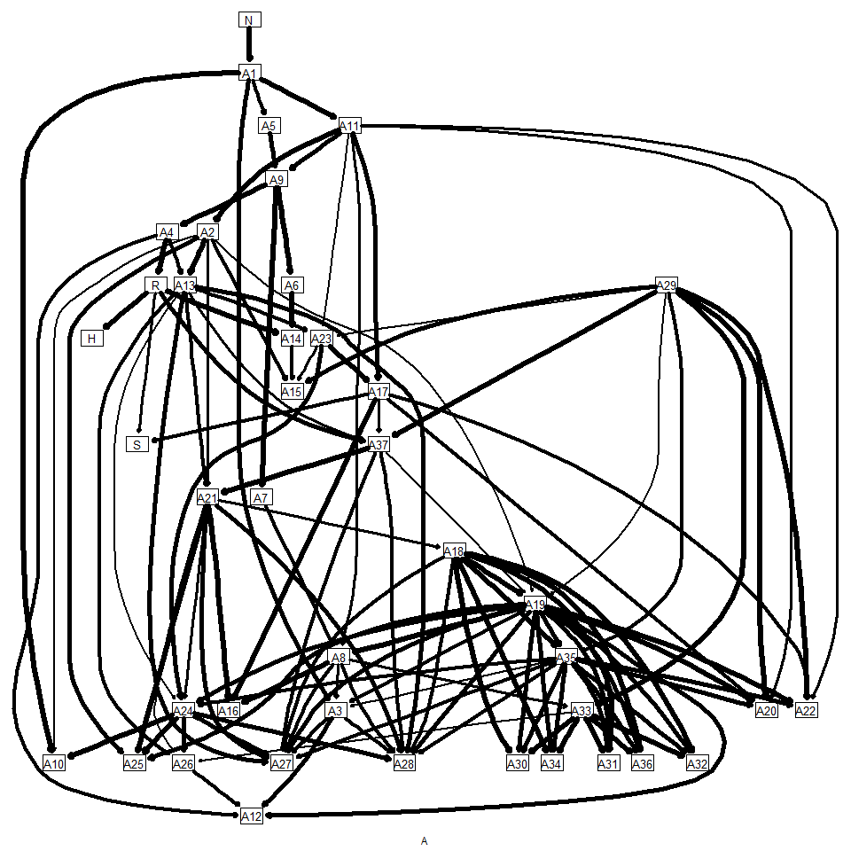

The start are “Number of neighborhoods” and Accepts.Credit.Cards. The final notes are Delivery, Takes.Reservations, lunch, dinner, breakfast, brunch, intimate, classy, hipster, touristy, upscale

the average predictive correlations by extracting the values from the 10 runs of cross-validation

|  | pred | post | pred | post | pred | post | pred | post |
| --- | --- | --- | --- | --- | --- | --- | --- | --- |
| S | 0.29 | 0.12 | 0.20 | 0.14 | 0.18 | -0.08 | 0.06 | 0.01 |
| H | 0.25 | 0.24 | 0.21 | -0.03 | -0.10 | -0.04 | 0.17 | 0.04 |
| R | 0.36 | 0.30 | 0.07 | 0.03 | 0.34 | 0.01 | 0.35 | 0.22 |
| N |  |  | -0.00 | 0.03 |  |  | -0.02 | -0.02 |
| A | 0.80 | 1.00 | 0.78 | 1.00 | 0.78 | 1.00 | 0.78 | 1.00 |